# weight_lifting_ML

Brian Farris

December 9, 2014

First, we download the data if it isn’t already stored locally and read into data frames.

```r
if (!file.exists("data")){
  dir.create("data")
}
destfile1 <- "./data/pml-training.csv"
destfile2 <- "./data/pml-testing.csv"

if (!file.exists(destfile1)){
  fileURL <- "https://d396qusza40orc.cloudfront.net/predmachlearn/pml-training.csv"
  download.file(fileURL,destfile=destfile1, method='curl')
  dateDownloaded1 <- date()
}
if (!file.exists(destfile2)){
  fileURL <- "https://d396qusza40orc.cloudfront.net/predmachlearn/pml-testing.csv"
  download.file(fileURL,destfile=destfile2, method='curl')
  dateDownloaded2 <- date()
}

TrainingData <- read.csv("./data/pml-training.csv",stringsAsFactors = FALSE)
TestingData <- read.csv("./data/pml-testing.csv",stringsAsFactors = FALSE)
```

Now we split the TrainingData set into a training portion and a validation portion, with 70% of data points going to the training portion and 30% going into the validation portion. We clean each by removing all the composite measurements, which have many NANs and do not add new information in principle, as they can be calculated from the rest of the data. We also remove the time information and the user_name, new_window, and num_window columns, as we don’t expect these to be predictive.

```r
library(dplyr)
CleanTrainingData <- select(TrainingData,-X,-user_name,-raw_timestamp_part_1,-raw_timestamp_part_2,-cvtd_timestamp,-new_window,-num_window,-grep("^min_",colnames(TrainingData)),
       -grep("^min_",colnames(TrainingData)),
       -grep("^max_",colnames(TrainingData)),
       -grep("^avg_",colnames(TrainingData)),
       -grep("^stddev_",colnames(TrainingData)),
       -grep("^var_",colnames(TrainingData)),
       -grep("^amplitude_",colnames(TrainingData)),
       -grep("^skewness_",colnames(TrainingData)),
       -grep("^kurtosis_",colnames(TrainingData)))
CleanTrainingData$classe <- as.factor(CleanTrainingData$classe)

library(caret)
inTrain <- createDataPartition(y=CleanTrainingData$classe,p=0.7,list=FALSE)
training <-CleanTrainingData[inTrain,]
validation <-CleanTrainingData[-inTrain,]

CleanTestingData <- select(TestingData,-X,-user_name,-raw_timestamp_part_1,-raw_timestamp_part_2,-cvtd_timestamp,-new_window,-num_window,-grep("^min_",colnames(TestingData)),
       -grep("^min_",colnames(TestingData)),
       -grep("^max_",colnames(TestingData)),
       -grep("^avg_",colnames(TestingData)),
       -grep("^stddev_",colnames(TestingData)),
       -grep("^var_",colnames(TestingData)),
       -grep("^amplitude_",colnames(TestingData)),
       -grep("^skewness_",colnames(TestingData)),
       -grep("^kurtosis_",colnames(TestingData)))
```

We train a series of random forest models, varying the number of trees used.

```r
if (!file.exists("model1.RDS")){
  model1 <- train(classe~.,data=training,method="rf",ntree=1)
  saveRDS(model1, "model1.RDS")
  } else{
    model1 = readRDS("model1.RDS")
    }
if (!file.exists("model2.RDS")){
  model2 <- train(classe~.,data=training,method="rf",ntree=2)
  saveRDS(model2, "model2.RDS")
  } else{
    model2 = readRDS("model2.RDS")
  }
if (!file.exists("model4.RDS")){
  model4 <- train(classe~.,data=training,method="rf",ntree=4)
  saveRDS(model4, "model4.RDS")
  } else{
    model4 = readRDS("model4.RDS")
  }
if (!file.exists("model8.RDS")){
  model8 <- train(classe~.,data=training,method="rf",ntree=8)
  saveRDS(model8, "model8.RDS")
  } else{
    model8 = readRDS("model8.RDS")
  }
if (!file.exists("model16.RDS")){
  model16 <- train(classe~.,data=training,method="rf",ntree=16)
  saveRDS(model16, "model16.RDS")
  } else{
    model16 = readRDS("model16.RDS")
  }
if (!file.exists("model32.RDS")){
  model32 <- train(classe~.,data=training,method="rf",ntree=32)
  saveRDS(model32, "model32.RDS")
} else{
  model32 = readRDS("model32.RDS")
}
if (!file.exists("model64.RDS")){
  model64 <- train(classe~.,data=training,method="rf",ntree=64)
  saveRDS(model64, "model64.RDS")
} else{
  model64 = readRDS("model64.RDS")
}
if (!file.exists("model128.RDS")){
  model128 <- train(classe~.,data=training,method="rf",ntree=128)
  saveRDS(model128, "model128.RDS")
} else{
  model128 = readRDS("model128.RDS")
}
if (!file.exists("model256.RDS")){
  model256 <- train(classe~.,data=training,method="rf",ntree=256)
  saveRDS(model256, "model256.RDS")
} else{
  model256 = readRDS("model256.RDS")
}
if (!file.exists("model512.RDS")){
  model512 <- train(classe~.,data=training,method="rf",ntree=512)
  saveRDS(model512, "model512.RDS")
} else{
  model512 = readRDS("model512.RDS")
}
```

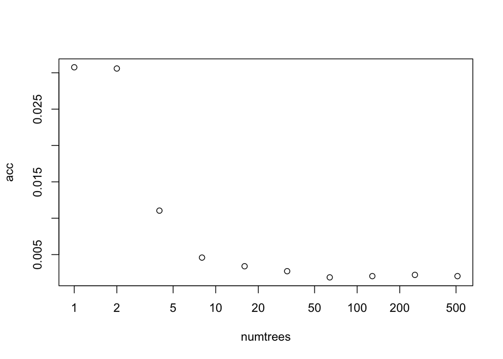

```r
err1 <- 1-sum(predict(model1,validation)==validation$classe)/length(validation$classe)
err2 <- 1-sum(predict(model2,validation)==validation$classe)/length(validation$classe)
err4 <- 1-sum(predict(model4,validation)==validation$classe)/length(validation$classe)
err8 <- 1-sum(predict(model8,validation)==validation$classe)/length(validation$classe)
err16 <- 1-sum(predict(model16,validation)==validation$classe)/length(validation$classe)
err32 <- 1-sum(predict(model32,validation)==validation$classe)/length(validation$classe)
err64 <- 1-sum(predict(model64,validation)==validation$classe)/length(validation$classe)
err128 <- 1-sum(predict(model128,validation)==validation$classe)/length(validation$classe)
err256 <- 1-sum(predict(model256,validation)==validation$classe)/length(validation$classe)
err512 <- 1-sum(predict(model512,validation)==validation$classe)/length(validation$classe)

numtrees <- c(1,2,4,8,16,32,64,128,256,512)
acc <- c(err1,err2,err4,err8,err16,err32,err64,err128,err256,err512)
plot(numtrees,acc,log="x")
```

Based on our cross-validation, we expect the out-of-sample error to be 0.0025.

Let’s now apply the model with 256 trees to the 20 test cases:

```r
test_results <- predict(model256,CleanTestingData)
print(test_results)
```

```
##  [1] B A B A A E D B A A B C B A E E A B B B
## Levels: A B C D E
```